# Project V

Juan P. Garces

November 2, 2016

### Exploratory Analysis

Below is a datagram showing The Effect of Vitamin C on Tooth Growth in Guinea Pigs

```
## 'data.frame':    60 obs. of  3 variables:
##  $ len : num  4.2 11.5 7.3 5.8 6.4 10 11.2 11.2 5.2 7 ...
##  $ supp: Factor w/ 2 levels "OJ","VC": 2 2 2 2 2 2 2 2 2 2 ...
##  $ dose: num  0.5 0.5 0.5 0.5 0.5 0.5 0.5 0.5 0.5 0.5 ...
```

The Plots below show a comparison between delivery method and dosage.

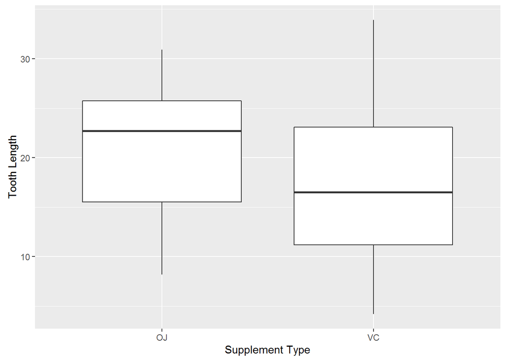

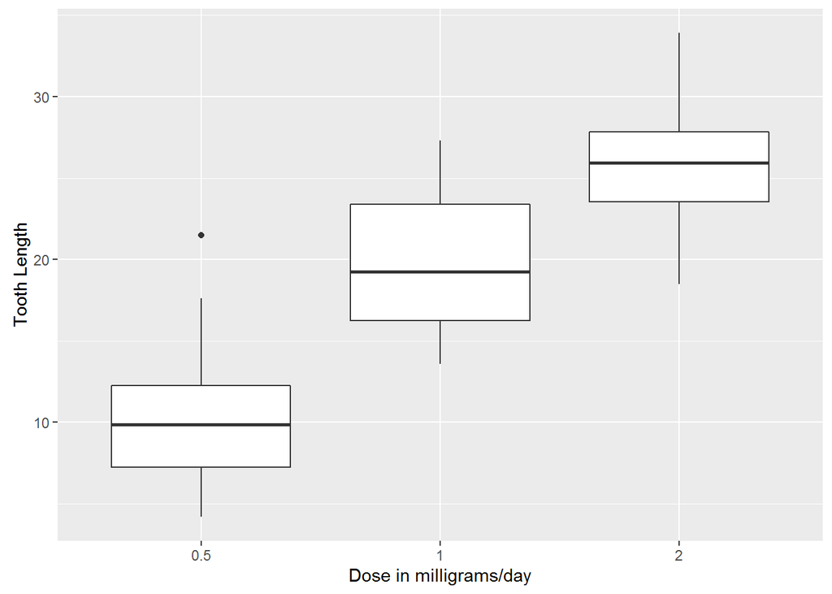

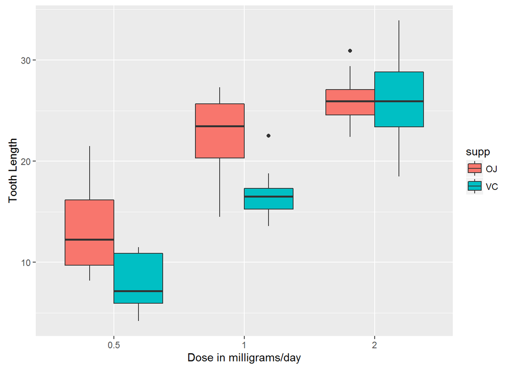

##### Means

I created sample means of the amount of growth expected for the two options: * Guinea pigs who receive a supplement as ascorbic acid (any dosage) * Guinea pigs who receive 2 mg of the supplement, delivered via orange juice

```r
S1<- filter(ToothGrowth, supp == "VC")
S2<- filter(ToothGrowth, supp == "OJ") # for Later Use
S3<- filter(ToothGrowth, (dose == 2.0 & supp == "OJ"))
t.test(S1$len, conf.level = .95)
```

```
##
##  One Sample t-test
##
## data:  S1$len
## t = 11.24, df = 29, p-value = 4.363e-12
## alternative hypothesis: true mean is not equal to 0
## 95 percent confidence interval:
##  13.87675 20.04992
## sample estimates:
## mean of x
##  16.96333
```

```r
t.test(S3$len, conf.level = .95)
```

```
##
##  One Sample t-test
##
## data:  S3$len
## t = 31.038, df = 9, p-value = 1.833e-10
## alternative hypothesis: true mean is not equal to 0
## 95 percent confidence interval:
##  24.16069 27.95931
## sample estimates:
## mean of x
##     26.06
```

### Inferential Analysis

I conducted t-tests to compare mean growth between several different pairs.

#### Comparison between abscorbic acid and orange juice supplement

I test the hypotheses $H_0 : \mu _{VC} = \mu _{OJ}$ versus $H_a : \mu _{VC} \ne \mu _{OJ}$

```r
t <- t.test(len~supp,ToothGrowth)
```

```
##
##  Welch Two Sample t-test
##
## data:  len by supp
## t = 1.9153, df = 55.309, p-value = 0.06063
## alternative hypothesis: true difference in means is not equal to 0
## 95 percent confidence interval:
##  -0.1710156  7.5710156
## sample estimates:
## mean in group OJ mean in group VC
##         20.66333         16.96333
```

The t-statistic of the test was 1.9152683 and the p-value was 0.0606345

#### Comparison between 1mg from orange juice and 2mg dose from orange juice supplement

I test the hypotheses $H_0 : \mu _{1mg} = \mu _{2mg}$ versus $H_a : \mu _{1mg} < \mu _{2mg}$

```r
S4<- filter(S2, dose == 1.0 | dose == 2.0)
t <- t.test(len~dose, S4,alternative = "less")
```

```
##
##  Welch Two Sample t-test
##
## data:  len by dose
## t = -2.2478, df = 15.842, p-value = 0.0196
## alternative hypothesis: true difference in means is less than 0
## 95 percent confidence interval:
##        -Inf -0.7486236
## sample estimates:
## mean in group 1 mean in group 2
##           22.70           26.06
```

#### Comparison between 1mg of abscorbic acid and 2mg of Abscorbic acid supplement

I test the hypotheses $H_0 : \mu _{1mg} = \mu _{2mg}$ versus $H_a : \mu _{1mg} < \mu _{2mg}$

```r
S5<- filter(S1, dose == 1.0 | dose == 2.0)
t <- t.test(len~dose, S5,alternative= "less")
```

```
##
##  Welch Two Sample t-test
##
## data:  len by dose
## t = -5.4698, df = 13.6, p-value = 4.578e-05
## alternative hypothesis: true difference in means is less than 0
## 95 percent confidence interval:
##       -Inf -6.346525
## sample estimates:
## mean in group 1 mean in group 2
##           16.77           26.14
```

#### Comparison between 1mg abscorbic acid 1mg and orange juice supplement

I test the hypotheses $H_0 : \mu _{1mg VC} = \mu _{1mg OJ}$ versus $H_a : \mu _{1mg VC} \ne \mu _{1mg OJ}$

```r
Both <- filter(ToothGrowth, dose == 1.0)
t <- t.test(len~supp, Both)
```

```
##
##  Welch Two Sample t-test
##
## data:  len by supp
## t = 4.0328, df = 15.358, p-value = 0.001038
## alternative hypothesis: true difference in means is not equal to 0
## 95 percent confidence interval:
##  2.802148 9.057852
## sample estimates:
## mean in group OJ mean in group VC
##            22.70            16.77
```

The t-statistic of the test was 4.0327696 and the p-value was 0.0010384

#### Comparison between 2mg abscorbic acid and 2mg orange juice supplement

I test the hypotheses $H_0 : \mu _{2mg VC} = \mu _{2mg OJ}$ versus $H_a : \mu _{2mg VC} \ne \mu _{2mg OJ}$

```r
Both <- filter(ToothGrowth, dose == 2.0)
t <- t.test(len~supp, Both)
```

```
##
##  Welch Two Sample t-test
##
## data:  len by supp
## t = -0.046136, df = 14.04, p-value = 0.9639
## alternative hypothesis: true difference in means is not equal to 0
## 95 percent confidence interval:
##  -3.79807  3.63807
## sample estimates:
## mean in group OJ mean in group VC
##            26.06            26.14
```

The t-statistic of the test was -0.0461361 and the p-value was 0.9638516